# MY472 - Assignment 5

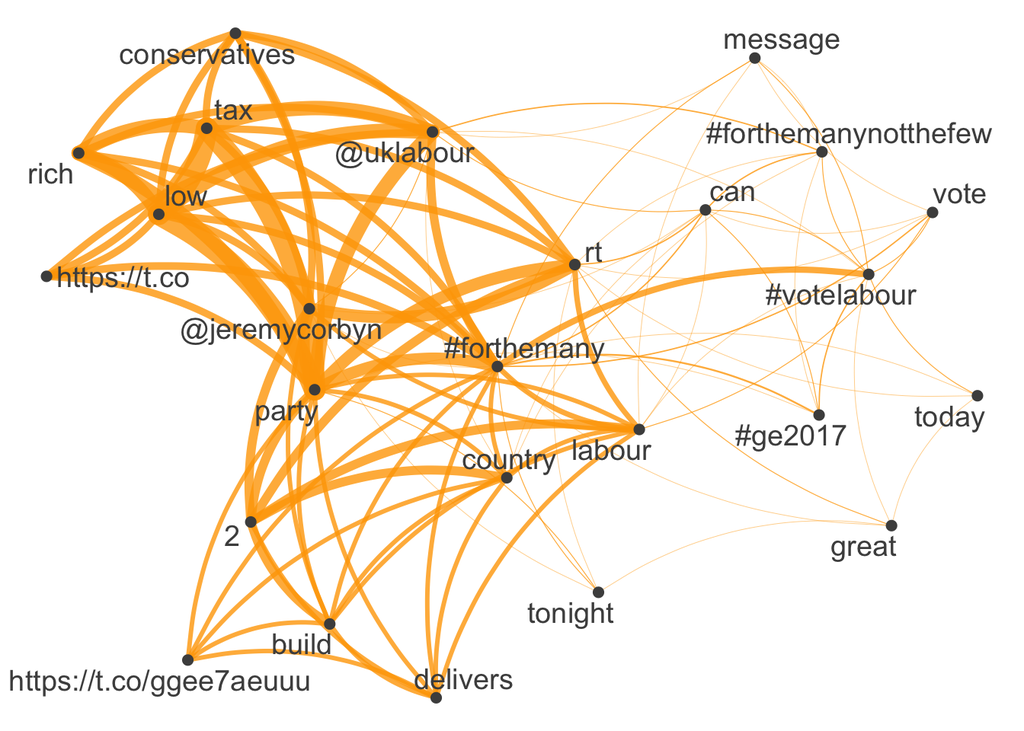

```r
# #forthemany

ftm_tweets <-  tweets_1$text %>%
   str_subset(pattern = "#forthemany")

ftm_toks <- ftm_tweets %>%
    tokens(remove_punct = TRUE) %>%
    tokens_tolower() %>%
    tokens_remove(pattern = stopwords("english"), padding = FALSE)

fcm_ftm <- fcm(ftm_toks, context = "window", tri = FALSE)
ftm_feat <- names(topfeatures(fcm_ftm, 25))
fcm_select(fcm_ftm, pattern = ftm_feat) %>%
    textplot_network(min_freq = 1, edge_color = "orange", edge_alpha = 0.8, edge_size = 5)
```

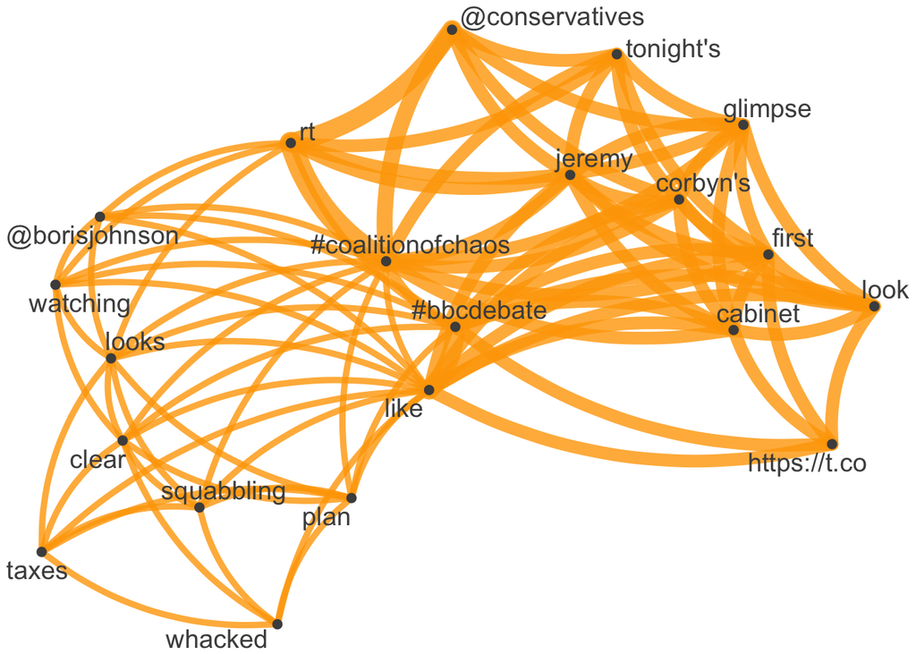

```r
# #coalitionofchaos

coc_tweets <-  tweets_1$text %>%
   str_subset(pattern = "#coalitionofchaos")

coc_toks <- coc_tweets %>%
    tokens(remove_punct = TRUE) %>%
    tokens_tolower() %>%
    tokens_remove(pattern = stopwords("english"), padding = FALSE)

fcm_coc <- fcm(coc_toks, context = "window", tri = FALSE)
coc_feat <- names(topfeatures(fcm_coc, 25))
fcm_select(fcm_coc, pattern = coc_feat) %>%
    textplot_network(min_freq = 2, edge_color = "orange", edge_alpha = 0.8, edge_size = 5)
```

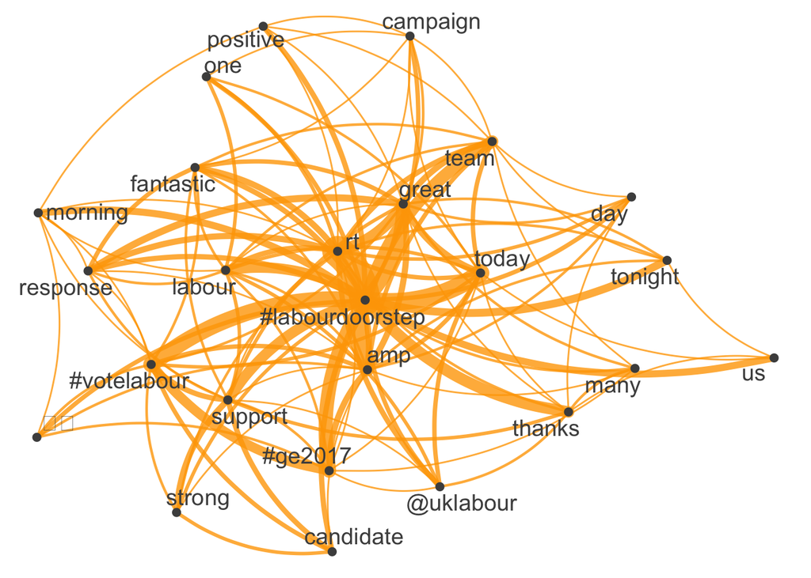

```r
# #labourdoorstep

lds_tweets <-  tweets_1$text %>%
   str_subset(pattern = "#labourdoorstep")

lds_toks <- lds_tweets %>%
    tokens(remove_punct = TRUE) %>%
    tokens_tolower() %>%
    tokens_remove(pattern = stopwords("english"), padding = FALSE)

fcm_lds <- fcm(lds_toks, context = "window", tri = FALSE)
lds_feat <- names(topfeatures(fcm_lds, 25))
fcm_select(fcm_lds, pattern = lds_feat) %>%
    textplot_network(min_freq = 2, edge_color = "orange", edge_alpha = 0.8, edge_size = 5)
```

```r
dbDisconnect(db_2)
```

**Answer: This hashtag and user network analysis will focus on the Labour Party, its motifs during the 2017 general election, Jeremy Corbyn, it’s leader at the time, and the Labour Doorstep app, an app which facilitated sharing of grassroots campaign activism for the Labour party. I chose these hashtags due to a large sample, as prior exploratory data analysis indicated to me that textplotting of SNP-based information will not be suitably robust due to limited sample size.**

**The first thing to note is that as data becomes more sparse (from @jeremycorbyn to #labourdoorstep), the connections seem to be less specific to the focal network node. For @jeremycorbyn, the key phrases, hashtags and users seem to revolve around plans for the future. This is likely due to being a non-incumbent competitor, and thus those who mentioned Corbyn didn’t focus on discussing his track record. As expected, there are a lot of ‘call to arms’ words used, such as ‘today,’ ‘#forthemany,’ ‘need,’ and ‘build.’ Typically, those who mentioned Corbyn used positive language. This interacts with mentions of ‘#bbcdebate’ and ‘debate,’ where it was noted that Corbyn performed particularly well and boosted his poll weighting as a result. Policy items such as ‘police’ and ‘security’ still remain relevant despite being surrounded by positive language.**

**Finally, I want to briefly talk about the #labourdoorstep hashtag. This app helps track and organise grassroots activism for Labour, which reminded me of Obama’s 2008 mobilisation strategy. The first thing that jumps out at me here is the clear sentiment. Words such as ‘thanks,’ ‘support,’ ‘fantastic,’ ‘strong,’ ‘great,’ ‘team’ and ‘campaign’ were central and frequent. Now, it’s likely that those who used the #labourdoorstep hashtag were ingratiated in Labour’s election campaign and so this hashtag provides us a means of comparison between those actively involved in grassroots election campagining and the rest of the population. The language is more focused, positive, and socially-oriented from an organisation perspective. This control over language and resulting cohesiveness and clarity is likely a product of training around desired messaging. I’m not aware of the Conservative party having an equivalent to the #labourdoorstep app, but if one was to emerge over the coming years then the study of the hashtag’s use could give us considerable insight into how campaigns maintain cohesion from the bottom-up when engaged in country-wide electoral battles.**

**Exercise 4. (30 points)**

In this open-ended exercise, the task is to study building an own database from multiple data sources which stores data on a topic you are interested in. You can e.g. download data with your browser (using APIs has no impact on the grade in this exercise) from data sources mentioned in previous assignments such as the [World Bank](https://data.worldbank.org/), [World Health Organization](https://www.who.int/data/gho), [St. Louis Federal Reserve](https://fred.stlouisfed.org/), [Our World in Data](https://ourworldindata.org/), and/or the [World Inequality Database](https://wid.world/data/). After downloading the data, reshape and process it with R packages such as `dplyr`, and then store the final tables in an `SQLite` database. This database should contain at least 2 tables.

More extensive, thought out, polished, and complex databases that combine data from different sources will receive higher marks here. Note, however, that the database should not be unnecessarily complex. For example, it would not make sense to store each economic indicator time-series in a separate table of a database. Rather, data should conceptually be bundled in tables. Also make sure not to repeat any unnecessary duplicate information in different tables of the database (e.g. in a hypothetical university database with a `students` and an `exams` table, both tables contain a `studentid` column but - because the tables can be joined via this column whenever necessary - the `exams` table does not repeat the student email addresses and other student information which is already stored in the `students` table).

If the final database is large, you can simply store it (and load it from) outside of the repository since we will grade the knitted HTML file. Database files can be uploaded to GitHub, however, note that if the database is large, GitHub push/pulls will be slower.

Download and process the data, then store it in the final `SQLite` database. Describe in markdown text why you structured the database the way you did. Then use SQL queries to:

1. Print out the total number of rows for each table in your database. Print out the column names for each table.
2. Print out the first 10 rows for each table.
3. Show whether all tables in the database can be (directly or indirectly) joined with SQL queries. Print out the first 5 rows of the joined tables.

**Answer: For Exercise 4, I will extract, transform and load data concerning conflict and political violence into a new database. My first table will use the country-year dyad as the primary key. It will contain data on national-level characteristics of a nation-state in a given year. My second table will concern instances of civil war onset per country-year. My third table will contain instances of domestic terrorism, derived from the University of Maryland’s ‘Global Terrorism Database.’ Finally, I will create a table that will show the number of foreign military interventions in a country per year. With these tables, a researcher can study the interaction between conflict events at different levels (from sub-national to transnational) and better understand which determinants are most powerful in predicting political violence events. I will deal with each table one at a time and describe how each connects to each other as I layer in more.**

```r
# Create Database
ex_4_db <- dbConnect(RSQLite::SQLite(), "~/Documents/Projects/ASDS/GitHub/MSc-ASDS-22/MY472/Assignments/assignment-05-christycoulson-data/assignment-05-ex-4-db.sqlite")
```

```r
###### These are the Correlates of War Country Codes. I will use these to standardise this connecting field.
COW_CC <- read_csv("~/Documents/Projects/ASDS/Conflict Prediction/Data/COW Country Codes.csv")
```

```r
COW_CC <- COW_CC %>% rename(country_code = CCode, Country = StateNme, Country_Abb = StateAbb)

###### This data is from the Polity5 project, which measures regime characteristics and level of democracy for polities in a given year. This will be the base for my first table, titled 'Country_Year_Demographics.'
Polity5 <- read_excel("~/Documents/Projects/ASDS/Conflict Prediction/Data/Polity5 1776-2018.xls")

Polity5 <- Polity5 %>% select(country, cyear, scode, ccode, year, democ, autoc, polity) %>%
  rename(Country = country, polity_score = polity, democ_score = democ, autoc_score = autoc, country_code = ccode,
         country_year = cyear, country_abbr = scode)

Country_Year_Demographics <- Polity5

###### This data was taken from the Correlates of War 'World Religion Dataset.' It contains the number of people in differing religious groups per country-year.
Religion <- read_csv("~/Documents/Projects/ASDS/Conflict Prediction/Data/World Religion National Dataset 1945-2010.csv")
Religion <- Religion %>% select(year, state, chrstgen, judgen, islmsun, islmshi, islmgen, budgen, zorogen, hindgen, sikhgen, shntgen, bahgen, taogen, jaingen, confgen, syncgen, anmgen,nonrelig,othrgen)

Country_Year_Demographics <- Country_Year_Demographics %>% left_join(Religion, by = c("country_code" = "state", "year" = "year"))

####### This data was taken from the World Bank and concerns the total population per country-year between the ages of 15-29. It comes in wide format and requires significant wrangling to get into a structure that suits us.
WB_15_29 <- read_csv("~/Documents/Projects/ASDS/Conflict Prediction/Data/World Bank Male pop 15-29 1960-2050.csv")
# Make column names first 4 characters to isolate years
names(WB_15_29) <- substring(names(WB_15_29), 1, 4)

# clean names with janitor package
WB_15_29 <- janitor::clean_names(WB_15_29)
# remove first character generated for years by janitor
names(WB_15_29) <- substring(names(WB_15_29), 2, 5)

WB_15_29 <- WB_15_29 %>% select(-eri_) # remove excess field
WB_15_29 <- WB_15_29 %>% rename(Country = oun, Country_Code = oun_, Type = eri) # rename columns

# Now, ready for gathering

WB_15_29 <- WB_15_29 %>%
  gather(year, figure, '1960':'2050')

WB_15_29$figure <- as.numeric(WB_15_29$figure)
young_men_totals <- as.data.frame(WB_15_29 %>%
  filter(Type %in% c("Population ages 15-19, male", 'Population ages 20-24, male', 'Population ages 25-29, male')) %>%
  group_by(Country, Country_Code, year) %>%
  summarise(figure = sum(figure))) # Generate total 15-29 number
population_totals <- as.data.frame(WB_15_29 %>%
  filter(Type == 'Population, total') %>%
  group_by(Country, Country_Code, year) %>%
  summarise(figure = sum(figure))) # Generate total pop number per country-year
young_men_population_totals <- left_join(young_men_totals, population_totals, by = c("Country" = "Country", "Country_Code" = "Country_Code", "year" = "year"))

young_men_population_totals <- young_men_population_totals %>% rename(young_men_population = figure.x, total_population = figure.y)

young_men_population_totals <- young_men_population_totals %>%
  mutate(percentage_young_men = young_men_population/total_population)

young_men_population_totals$year <- as.double(young_men_population_totals$year)

young_men_population_totals <- young_men_population_totals %>%
  select(-Country)

Country_Year_Demographics <- Country_Year_Demographics %>% left_join(young_men_population_totals, by = c("country_abbr" = "Country_Code", "year" = "year"))


###### This data is taken from the World Bank, and contains YoY population growth figures.
pop_growth <- read_csv("~/Documents/Projects/ASDS/Conflict Prediction/Data/Population Growth 1960-2005.csv")
names(pop_growth) <- substring(names(pop_growth), 1, 4) # Make column names first 4 charactrs to isolate years
pop_growth <- janitor::clean_names(pop_growth) # clean names
names(pop_growth) <- substring(names(pop_growth), 2, 5) # remove first character generated for years by janitor

pop_growth <- pop_growth %>% select(-eri_, -oun) # remove excess field
pop_growth <- pop_growth %>% rename(Country_Code = oun_, Type = eri) # rename columns

pop_growth <- pop_growth %>%
  filter(Type == 'Population growth (annual %)')

pop_growth_tidy <- pop_growth %>%
  gather(year, figure, '1960':'2050') %>%
  rename(pop_growth_YoY = figure) %>%
  select(-Type)

# make double for joining
pop_growth_tidy$year <- as.double(pop_growth_tidy$year)

Country_Year_Demographics <- Country_Year_Demographics %>% left_join(pop_growth_tidy, by = c("country_abbr" = "Country_Code", "year" = "year")) %>%
  arrange(desc(chrstgen))

head(Country_Year_Demographics)
```

```
## # A tibble: 6 × 30
##   Country   count…¹ count…² count…³  year democ…⁴ autoc…⁵ polit…⁶ chrst…⁷ judgen
##   <chr>       <dbl> <chr>     <dbl> <dbl>   <dbl>   <dbl>   <dbl>   <dbl>  <dbl>
## 1 United S…   22010 USA           2  2010      10       0      10  2.33e8 5.94e6
## 2 United S…   22005 USA           2  2005      10       0      10  2.26e8 5.54e6
## 3 United S…   22000 USA           2  2000      10       0      10  2.20e8 5.01e6
## 4 United S…   21995 USA           2  1995      10       0      10  2.16e8 5.26e6
## 5 United S…   21990 USA           2  1990      10       0      10  2.14e8 5.51e6
## 6 United S…   21985 USA           2  1985      10       0      10  2.00e8 7.51e6
## # … with 20 more variables: islmsun <dbl>, islmshi <dbl>, islmgen <dbl>,
## #   budgen <dbl>, zorogen <dbl>, hindgen <dbl>, sikhgen <dbl>, shntgen <dbl>,
## #   bahgen <dbl>, taogen <dbl>, jaingen <dbl>, confgen <dbl>, syncgen <dbl>,
## #   anmgen <dbl>, nonrelig <dbl>, othrgen <dbl>, young_men_population <dbl>,
## #   total_population <dbl>, percentage_young_men <dbl>, pop_growth_YoY <chr>,
## #   and abbreviated variable names ¹country_year, ²country_abbr, ³country_code,
## #   ⁴democ_score, ⁵autoc_score, ⁶polity_score, ⁷chrstgen
```

```r
# Write Table 1 to DB
dbWriteTable(ex_4_db, "Country_Year_Demographics", Country_Year_Demographics, overwrite = TRUE)
```

**Table 1: Country-Year Characteristics**

**In my first table, I have included a number of variables that have been theorised to have had an impact on the propensity for conflict in a given nation at a given time. The potential list of variables to be added here is extensive, but these demographic variables have a multi-decade history of being associated with the probability of conflict occurring. First, I include the country name, year, and two different kind of country codes for joins to different datasets. Next, I include the democracy and autocracy score from Polity5, alongside the overall Polity score for that country-year dyad. Following this, I added the number of people per country-year in each religious group. However, this data is only collected every 5 years. I have not performed calculations to fill in missing data as I want to allow the researchers with the necessary flexibility to justify their own process for dealing with missing data. My suggestion would be to lag numbers and aggregate over every 5 year period as populations are typically fairly statistic. However, this substantive justification means that ‘events’ that drastically affect a country’s religious distribution would be ignored. My next fields show the percentage of the population that are male and between 15-29. Finally, I have YoY population growth. The most unique field, and thus the primary key if one was to count instances in this data - is the country_year field. However, all joins are performed on a combination of a country indicator, either ‘country_code’ or ‘country_abbr’ and year.**

Data Points:

Country-year data = Country to year (5 fields)

Level of Democracy = democ_score, autoc_score and polity_score (3 fields)

Religious fractionalisation = chrstgen to othrgen (18 fields)

% population male and 15-29 years old = young_men_population, total_population & percentage_young_men (3 fields)

YoY population growth = pop_growth_YoY (1 field)

**I use the Correlates of War country-codes to act as a connector between these disparate data sources. I add Polity (regime characteristics) data from the Polity5 project, which can be reviewed here: https://www.systemicpeace.org/polityproject.html. These fields act as the base for my first table. I have included national religious characteristics, taken from the Correlates of War project, so that a researcher might explore religous heterogeneity and its impact on conflict. I have population data on the proportion of the population that are male and between the ages of 15-29, and these individuals have been evidenced to be more easily mobilised in conflict due to either greed or grievance. Finally, I will include YoY population growth to facilitate exploring whether rapidly changing populations are more prone to conflict. For my next table, I will look at instances of civil war onset.**

```r
cw_onset <- read_csv("~/Documents/Projects/ASDS/Conflict Prediction/Data/ucdp-intrastate-country-level-onset-dataset.csv")
Civil_War_Onset <- cw_onset %>%
  rename(country_abbr = abc, Country = name, new_conflict = newconf) %>%
  select(-conflict_ids)

head(Civil_War_Onset)
```

```
## # A tibble: 6 × 12
##   country_abbr Country   year gwno_a new_c…¹ onset1 onset2 onset3 onset5 onset10
##   <chr>        <chr>    <dbl>  <dbl>   <dbl>  <dbl>  <dbl>  <dbl>  <dbl>   <dbl>
## 1 USA          United …  1946      2       0      0      0      0      0       0
## 2 USA          United …  1947      2       0      0      0      0      0       0
## 3 USA          United …  1948      2       0      0      0      0      0       0
## 4 USA          United …  1949      2       0      0      0      0      0       0
## 5 USA          United …  1950      2       0      0      0      0      0       0
## 6 USA          United …  1951      2       0      0      0      0      0       0
## # … with 2 more variables: onset20 <dbl>, year_prev <dbl>, and abbreviated
## #   variable name ¹new_conflict
```

```r
# Write Table 2 to DB
dbWriteTable(ex_4_db, "Civil_War_Onset", Civil_War_Onset, overwrite = TRUE)
```

**Table 2: Civil War Onset**

**This table will contain instances of civil war onset, by country-year. Civil War is here defined as a conflict between state and non-state actors within a given country that resulted in at least 25 battle deaths that year. This means that if there was a civil war that *BEGUN* in this year, it will be counted. This data is taken from the Uppsala Conflict Data Program (UCDP), and is thus in fairly clean format. I simply need to rename and remove a few superfluous fields and I’m ready to write this table to my db. This table contains both country and year. It also contains whether a new civil conflict occurred during this year. The gwno field has been kept here for scaleability. This field allows joining with other UCDP data sets and so I have retained it in case I want to expand my database structure in the future. The ‘onset’ fields are logical and have a value of 1 if it has been at least the number of years shown in the column name since the last civil conflict. year_prev shows the previous year where a civil conflict occurred in this country. This table facilitates time-series analysis as these columns can be used to better understand how periods of peace mgith impact the propensity for future conflict.**

Data Points:

country/year info = country_abbr to year (3 fields)

superfluous connector for other UCDP data = gwno_a (1 field)

Indicator for new conflict this country-year = new_conflict (1 field)

years since last civil war onset = onset1 to onset20 (6 fields)

year of previous civil conflict = year_prev (1 field)

**This table connects to my main Country_Year_Demographics table by Country_Year_Demographics.country_abbr = Civil_War_Onset.country_abbr AND Country_Year_Demographics.year = Civil_War_Onset.year.**

```r
Terrorism <- read_excel("~/Documents/Projects/ASDS/Conflict Prediction/Data/Global_Terrorism_Database_September_23.xlsx")

Terrorism %>%
  filter(country == natlty1) %>%
  summarise(domestic_terrorism_attacks = n()) # 185507 domestic terrorist attacks
```

```
## # A tibble: 1 × 1
##   domestic_terrorism_attacks
##                        <int>
## 1                     185507
```

```r
# Domestic terrorism, as a subset of terrorism more generally, is conducted within the geospatial boundaries of a given state and is engaged in against a citizen or property of said country.

Domestic_Terrorism <- Terrorism %>%
  filter(country == natlty1)

Domestic_Terrorism <- Domestic_Terrorism %>%
  select(eventid, iyear, imonth, iday, country, country_txt, region_txt, latitude, longitude, location,
         attacktype1_txt, targtype1_txt, targsubtype1_txt, target1, natlty1_txt) %>%
  rename(terrorism_event_id = eventid, year = iyear, month = imonth, day = iday, Country_Code = country, Country = country_txt, Region = region_txt, attack_type = attacktype1_txt, target_type = targtype1_txt, subtarget_type = targsubtype1_txt, target = target1, target_nationality = natlty1_txt )

head(Domestic_Terrorism)
```

```
## # A tibble: 6 × 15
##   terrorism_e…¹  year month   day Count…² Country Region latit…³ longi…⁴ locat…⁵
##           <dbl> <dbl> <dbl> <dbl>   <dbl> <chr>   <chr>    <dbl>   <dbl> <chr>
## 1  197000000001  1970     7     2      58 Domini… Centr…    18.5   -70.0 <NA>
## 2  197001010002  1970     1     1     217 United… North…    37.0   -89.2 <NA>
## 3  197001020001  1970     1     2     218 Uruguay South…   -34.9   -56.2 <NA>
## 4  197001020002  1970     1     2     217 United… North…    37.8  -122.  Edes S…
## 5  197001020003  1970     1     2     217 United… North…    43.1   -89.4 <NA>
## 6  197001030001  1970     1     3     217 United… North…    43.1   -89.4 <NA>
## # … with 5 more variables: attack_type <chr>, target_type <chr>,
## #   subtarget_type <chr>, target <chr>, target_nationality <chr>, and
## #   abbreviated variable names ¹terrorism_event_id, ²Country_Code, ³latitude,
## #   ⁴longitude, ⁵location
```

```r
# Write Table 3 to DB
dbWriteTable(ex_4_db, "Domestic_Terrorism", Domestic_Terrorism, overwrite = TRUE)
```

**Table 3: Domestic Terrorism**

```r
IMI_1947_2005 <- read_excel("~/Documents/Projects/ASDS/Conflict Prediction/Data/IMI-1947-2005.xls")

# First, need to separate target and intervener data so that we can transform around targets to operationalise measurement of magnitude of intervention in target-country-year.

IMI <- left_join(IMI_1947_2005, COW_CC, by = c("intervener" = "country_code")) %>% view()
IMI <- IMI %>% rename(Intervener_Country_Code = Country_Abb, Intervener_Country = Country)

IMI <- IMI %>% left_join(COW_CC, by = c("target" = "country_code"))
IMI <- IMI %>% rename(Intervention_Target_Country_Code = Country_Abb, Intervention_Target_Country = Country)

IMI <- IMI %>% mutate(startyear = as.numeric(substr(start,1,4)), endyear = as.numeric(substr(IMI$end,1,4)))

IMI <- IMI %>%
 group_by(Intervention_Target_Country_Code, Intervention_Target_Country, startyear) %>%
 summarise(no_of_intervening_countries = n()) %>%
 arrange(desc(no_of_intervening_countries))
```

[output not shown]

```r
# Write Table 4 to DB.
dbWriteTable(ex_4_db, "IMI", IMI, overwrite = TRUE)
```

_Table 4: International Foreign Military Interventions per Target Country-Year__

**This table contains the number of foreign military interventions per target country from 1947 to 2005. It was taken from the International Military Interventions database. The definition for an international foreign military intervention can be found here: https://www.jstor.org/stable/25654438. This data can be examined relative to country-year demographics, instances of civil war onset and incidences of domestic terrorism to see if interventions are more likely to occur in differing conditions. In this table, i include the intervention target country name and country code. I also include the startyear of said interventions and the number of interventions by foreign powers during said year. no_of_intervening countries is 0 or a positive integer, and can be used to examine magnitude of foreign interventions. For example, Iraq in 2003 saw 34 foreign powers engage in a foreign military intervention within their borders, the highest in our database. This table joins with my main table via Country_Year_Demographics.country_abbr = IMI.Intervention_Target_Country_Code AND Country_Year_Demographics.year = IMI.startyear. Now, I will query my database using SQLite to demonstrate joins, structures and data.**

**1. Print out the total number of rows for each table in your database. Print out the column names for each table.**

```r
# Column Names
dbListFields(ex_4_db, "Country_Year_Demographics")
```

```
##  [1] "Country"              "country_year"         "country_abbr"
##  [4] "country_code"         "year"                 "democ_score"
##  [7] "autoc_score"          "polity_score"         "chrstgen"
## [10] "judgen"               "islmsun"              "islmshi"
## [13] "islmgen"              "budgen"               "zorogen"
## [16] "hindgen"              "sikhgen"              "shntgen"
## [19] "bahgen"               "taogen"               "jaingen"
## [22] "confgen"              "syncgen"              "anmgen"
## [25] "nonrelig"             "othrgen"              "young_men_population"
## [28] "total_population"     "percentage_young_men" "pop_growth_YoY"
```

```r
dbListFields(ex_4_db, "Civil_War_Onset")
```

```
##  [1] "country_abbr" "Country"      "year"         "gwno_a"       "new_conflict"
##  [6] "onset1"       "onset2"       "onset3"       "onset5"       "onset10"
## [11] "onset20"      "year_prev"
```

```r
dbListFields(ex_4_db, "Domestic_Terrorism")
```

```
##  [1] "terrorism_event_id" "year"               "month"
##  [4] "day"                "Country_Code"       "Country"
##  [7] "Region"             "latitude"           "longitude"
## [10] "location"           "attack_type"        "target_type"
## [13] "subtarget_type"     "target"             "target_nationality"
```

```r
dbListFields(ex_4_db, "IMI")
```

```
## [1] "Intervention_Target_Country_Code" "Intervention_Target_Country"
## [3] "startyear"                        "no_of_intervening_countries"
```

```r
# Number of Rows
dbGetQuery(ex_4_db,
           "SELECT COUNT(*) AS NumberofRows_Country_Year_Demographics
            FROM Country_Year_Demographics
           ")
```

```
##   NumberofRows_Country_Year_Demographics
## 1                                  17574
```

```r
dbGetQuery(ex_4_db,
           "SELECT COUNT(*) AS NumberofRows_Civil_War_Onset
            FROM Civil_War_Onset
           ")
```

```
##   NumberofRows_Civil_War_Onset
## 1                        10142
```

```r
dbGetQuery(ex_4_db,
           "SELECT COUNT(*) AS NumberofRows_Domestic_Terrorism
            FROM Domestic_Terrorism
           ")
```

```
##   NumberofRows_Domestic_Terrorism
## 1                          185507
```

```r
dbGetQuery(ex_4_db,
           "SELECT COUNT(*) AS NumberofRows_IMI
            FROM IMI
           ")
```

```
##   NumberofRows_IMI
## 1              692
```

**2. Print out the first 10 rows for each table.**

```r
# First 10 Rows
dbGetQuery(ex_4_db,
           "SELECT *
            FROM Country_Year_Demographics
            LIMIT 10
           ")
```

```
##          Country country_year country_abbr country_code year democ_score
## 1  United States        22010          USA            2 2010          10
## 2  United States        22005          USA            2 2005          10
## 3  United States        22000          USA            2 2000          10
## 4  United States        21995          USA            2 1995          10
## 5  United States        21990          USA            2 1990          10
## 6  United States        21985          USA            2 1985          10
## 7  United States        21980          USA            2 1980          10
## 8  United States        21975          USA            2 1975          10
## 9  United States        21970          USA            2 1970           8
## 10        Brazil      1402010          BRA          140 2010           8
##    autoc_score polity_score  chrstgen  judgen islmsun islmshi islmgen  budgen
## 1            0           10 233111307 5942248 2476980  337770 2814750 3410236
## 2            0           10 226464805 5536622 2363129  322245 2685374 3682694
## 3            0           10 219818305 5010424 2249277  306720 2555997 2449569
```

[output cut: 40 more lines]

```r
dbGetQuery(ex_4_db,
           "SELECT *
            FROM Civil_War_Onset
            LIMIT 10
           ")
```

```
##    country_abbr                  Country year gwno_a new_conflict onset1 onset2
## 1           USA United States of America 1946      2            0      0      0
## 2           USA United States of America 1947      2            0      0      0
## 3           USA United States of America 1948      2            0      0      0
## 4           USA United States of America 1949      2            0      0      0
## 5           USA United States of America 1950      2            0      0      0
## 6           USA United States of America 1951      2            0      0      0
## 7           USA United States of America 1952      2            0      0      0
## 8           USA United States of America 1953      2            0      0      0
## 9           USA United States of America 1954      2            0      0      0
## 10          USA United States of America 1955      2            0      0      0
##    onset3 onset5 onset10 onset20 year_prev
## 1       0      0       0       0        NA
## 2       0      0       0       0        NA
## 3       0      0       0       0        NA
## 4       0      0       0       0        NA
## 5       0      0       0       0        NA
## 6       0      0       0       0        NA
## 7       0      0       0       0        NA
## 8       0      0       0       0        NA
## 9       0      0       0       0        NA
## 10      0      0       0       0        NA
```

```r
dbGetQuery(ex_4_db,
           "SELECT *
            FROM Domestic_Terrorism
            LIMIT 10
           ")
```

```
##    terrorism_event_id year month day Country_Code            Country
## 1        197000000001 1970     7   2           58 Dominican Republic
## 2        197001010002 1970     1   1          217      United States
## 3        197001020001 1970     1   2          218            Uruguay
## 4        197001020002 1970     1   2          217      United States
## 5        197001020003 1970     1   2          217      United States
## 6        197001030001 1970     1   3          217      United States
## 7        197001050001 1970     1   1          217      United States
## 8        197001060001 1970     1   6          217      United States
## 9        197001090001 1970     1   9          217      United States
## 10       197001090002 1970     1   9          217      United States
##                         Region  latitude  longitude                location
## 1  Central America & Caribbean  18.45679  -69.95116                    <NA>
## 2                North America  37.00511  -89.17627                    <NA>
## 3                South America -34.89115  -56.18721                    <NA>
```

[output cut: 51 more lines]

```r
dbGetQuery(ex_4_db,
           "SELECT *
            FROM IMI
            LIMIT 10
           ")
```

```
##    Intervention_Target_Country_Code      Intervention_Target_Country startyear
## 1                               IRQ                             Iraq      2003
## 2                               SAU                     Saudi Arabia      1990
## 3                               KUW                           Kuwait      1990
## 4                               EGY                            Egypt      1973
## 5                               LEB                          Lebanon      1982
## 6                               ALB                          Albania      1997
## 7                               DRC Democratic Republic of the Congo      1978
## 8                               ERI                          Eritrea      1998
## 9                               ISR                           Israel      1948
## 10                              AFG                      Afghanistan      2001
##    no_of_intervening_countries
## 1                           34
## 2                           29
## 3                           19
## 4                           10
## 5                           10
## 6                            8
## 7                            8
## 8                            8
## 9                            8
## 10                           7
```

**3. Show whether all tables in the database can be (directly or indirectly) joined with SQL queries. Print out the first 5 rows of the joined tables.**

```r
# Join to demonstrate how tables interact with each other.
dbGetQuery(ex_4_db,
           "SELECT *
            FROM Country_Year_Demographics cyd
            LEFT JOIN Civil_War_Onset cw
            ON cyd.country_abbr = cw.country_abbr AND cyd.year = cw.year
            LEFT JOIN Domestic_Terrorism dt
            ON cyd.country_code = dt.Country_Code AND cyd.year = dt.year
            LEFT JOIN IMI mi
            ON cyd.country_abbr = mi.Intervention_Target_Country_Code AND cyd.year = mi.startyear
            LIMIT 5
           ")
```

```
##         Country country_year country_abbr country_code year democ_score
## 1 United States        22010          USA            2 2010          10
## 2 United States        22005          USA            2 2005          10
## 3 United States        22000          USA            2 2000          10
## 4 United States        21995          USA            2 1995          10
## 5 United States        21990          USA            2 1990          10
##   autoc_score polity_score  chrstgen  judgen islmsun islmshi islmgen  budgen
## 1           0           10 233111307 5942248 2476980  337770 2814750 3410236
## 2           0           10 226464805 5536622 2363129  322245 2685374 3682694
## 3           0           10 219818305 5010424 2249277  306720 2555997 2449569
## 4           0           10 215593975 5259463 2134332  291045 2425377 1608346
## 5           0           10 214425162 5508504 2019386  275371 2294757 1575481
##   zorogen hindgen sikhgen shntgen bahgen taogen jaingen confgen syncgen  anmgen
## 1 1644887 1797698  406908  156375 482784  11768   83984   91591  803181 1773577
## 2 1554443 1311442  269862   60560 456767  11134   79459   86656  672506 1066695
```

[output cut: 45 more lines]

**Final Note**

**To summarise, I want to discuss a key limitation of this data, availability. Each dataset has differing temporal coverage. Thus, it’s important to state this limitation below. For each dataset used, I will define the temporal boundaries of data coverage below.**

Polity5 - From 1800 until 2018.

Religion - From 1945 to 2010.

Male Population % aged 15-29 - 1960 until 2050 predictions.

Civil War Onset - 1946 to 2017.

Domestic Terrorism - 1970 to 2020.

International Foreign Military Interventions - 1947 to 2005.

**As mentioned prior, I haven’t transformed data to fill in missing data because of the substantive impact this might have on theory testing. Instead, I will allow the researcher to use prior empirics and theory to determine how best to proceed for each research endevour. I have worked to omit any superfluous variables from the initial datasets whilst retaining any where value variability might add an analytical quality.This balancing act is crucial to the logic behind my database structure, which I hope I’ve demonstrated.** __